# Pricing Car Insurance

Insure-ly You’re Joking, Mr. Feynman

Mick Cooney

February 27, 2017

# Background

# Computational Actuarial Science in R

[figure not shown]

# Insurance Business

Life Insurance

General Insurance

(Health Insurance)

Pay premia

If event occurs, receive payout

How do we calculate premia?

# Life Insurance

Monthly or annual premia

Contingent annuity

Life Tables

# Pricing General Insurance

Typically 1-year policies

(but not always)

Frequency / Severity Model

Exposure vs Claims

Heavy use of GLMs

Combine claim rate with claim amount to price

Claim Rate $\longrightarrow$ Poisson

Claim Amount $\longrightarrow$ Gamma

Need policy and claim data

Package `CASDatasets`

`freMPTLfreq` and `freMPTLsev`

More datasets in book

# Data Loading and Inspection

```r
freMTPLfreq %>% glimpse
```

```
## Observations: 413,169
## Variables: 10
## $ PolicyID  <int> 1, 2, 3, 4, 5, 6, 7, 8, 9, 10, 11, 12, 13, 14, 15, 16, 17...
## $ ClaimNb   <int> 0, 0, 0, 0, 0, 0, 0, 0, 0, 0, 0, 0, 0, 0, 0, 0, 0, 0, 0, ...
## $ Exposure  <dbl> 0.09, 0.84, 0.52, 0.45, 0.15, 0.75, 0.81, 0.05, 0.76, 0.3...
## $ Power     <fctr> g, g, f, f, g, g, d, d, d, i, f, f, e, e, e, e, e, e, i,...
## $ CarAge    <int> 0, 0, 2, 2, 0, 0, 1, 0, 9, 0, 2, 2, 0, 0, 0, 0, 0, 0, 0, ...
## $ DriverAge <int> 46, 46, 38, 38, 41, 41, 27, 27, 23, 44, 32, 32, 33, 33, 3...
## $ Brand     <fctr> Japanese (except Nissan) or Korean, Japanese (except Nis...
## $ Gas       <fctr> Diesel, Diesel, Regular, Regular, Diesel, Diesel, Regula...
## $ Region    <fctr> R72, R72, R31, R31, R52, R52, R72, R72, R31, R11, R24, R...
## $ Density   <int> 76, 76, 3003, 3003, 60, 60, 695, 695, 7887, 27000, 23, 23...
```

```r
freMTPLfreq %>% head
```

```
##   PolicyID ClaimNb Exposure Power CarAge DriverAge
## 1        1       0     0.09     g      0        46
## 2        2       0     0.84     g      0        46
## 3        3       0     0.52     f      2        38
## 4        4       0     0.45     f      2        38
## 5        5       0     0.15     g      0        41
## 6        6       0     0.75     g      0        41
##                                Brand     Gas Region Density
## 1 Japanese (except Nissan) or Korean  Diesel    R72      76
## 2 Japanese (except Nissan) or Korean  Diesel    R72      76
## 3 Japanese (except Nissan) or Korean Regular    R31    3003
## 4 Japanese (except Nissan) or Korean Regular    R31    3003
## 5 Japanese (except Nissan) or Korean  Diesel    R52      60
## 6 Japanese (except Nissan) or Korean  Diesel    R52      60
```

```r
freMTPLsev %>% glimpse
```

```
## Observations: 16,181
## Variables: 2
## $ PolicyID    <int> 63987, 310037, 314463, 318713, 309380, 309380, 318738, ...
## $ ClaimAmount <int> 1172, 1905, 1150, 1220, 55077, 7593, 1176, 1202, 1203, ...
```

```r
freMTPLsev %>% head
```

```
##   PolicyID ClaimAmount
## 1    63987        1172
## 2   310037        1905
## 3   314463        1150
## 4   318713        1220
## 5   309380       55077
## 6   309380        7593
```

# Combine Tables

```r
combined_tbl %>% head
```

```
## # A tibble: 6 × 12
##   policy_id claim_nb exposure  power car_age driver_age
##       <int>    <int>    <dbl> <fctr>   <int>      <int>
## 1         1        0     0.09      g       0         46
## 2         2        0     0.84      g       0         46
## 3         3        0     0.52      f       2         38
## 4         4        0     0.45      f       2         38
## 5         5        0     0.15      g       0         41
## 6         6        0     0.75      g       0         41
## # ... with 6 more variables: brand <fctr>, gas <fctr>, region <fctr>,
## #   density <int>, claim_count <dbl>, claim_total <dbl>
```

```r
combined_tbl %>% filter(claim_nb != claim_count)
```

```
## # A tibble: 0 × 12
## # ... with 12 variables: policy_id <int>, claim_nb <int>, exposure <dbl>,
## #   power <fctr>, car_age <int>, driver_age <int>, brand <fctr>, gas <fctr>,
## #   region <fctr>, density <int>, claim_count <dbl>, claim_total <dbl>
```

# Data Exploration

# Univariate Exploration

Look at each variable

Create histograms, bar charts etc

### claim_count

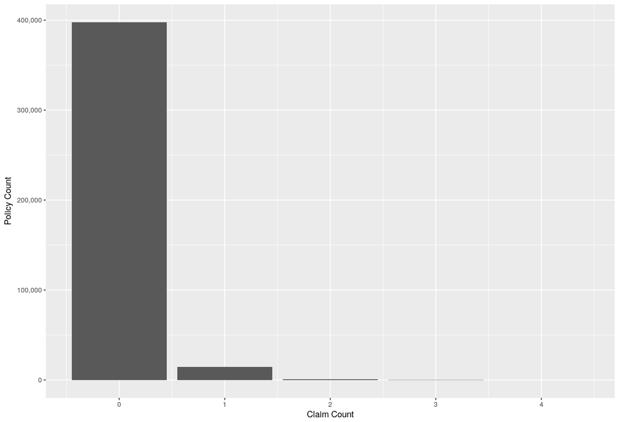

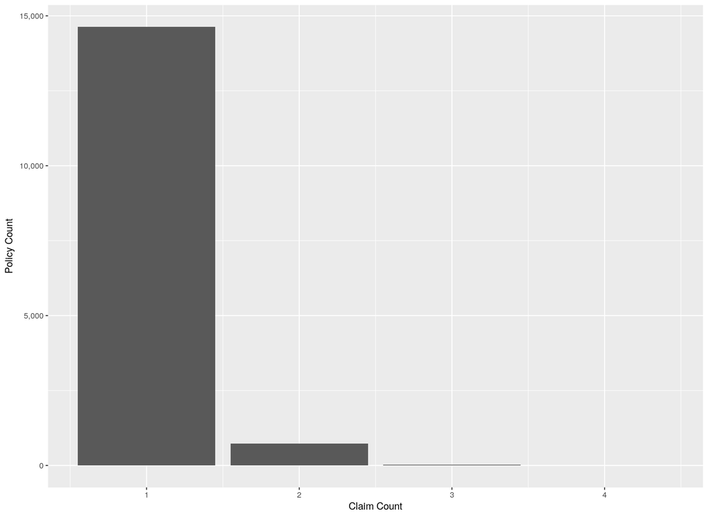

### claim_amount

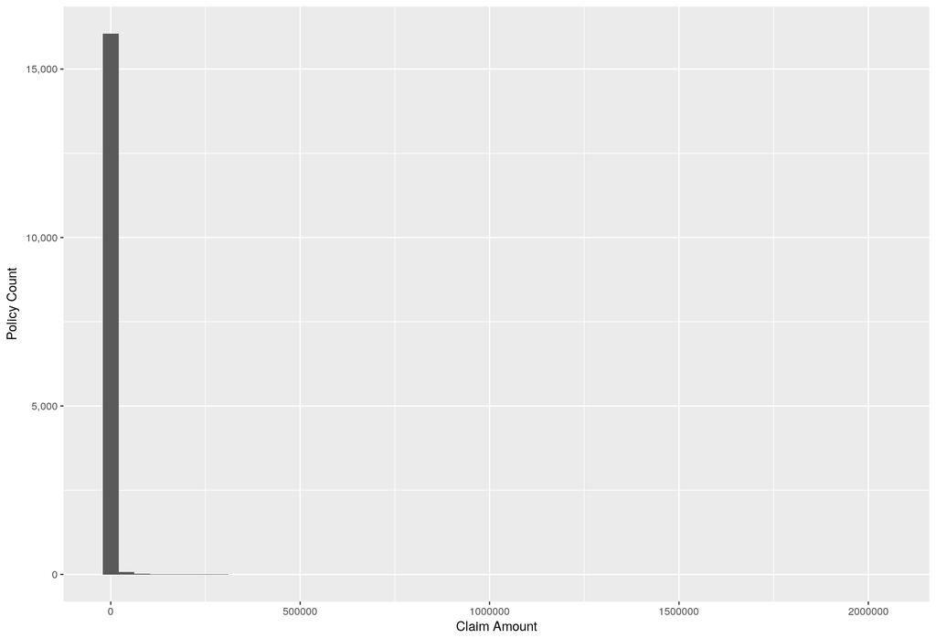

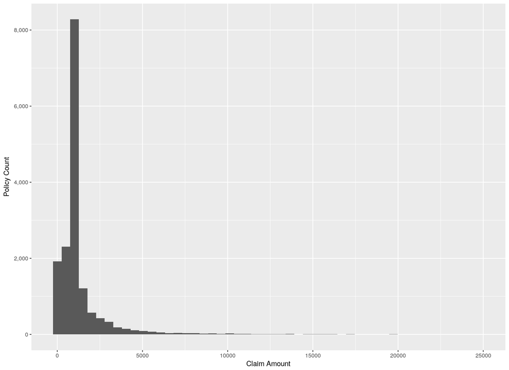

### exposure

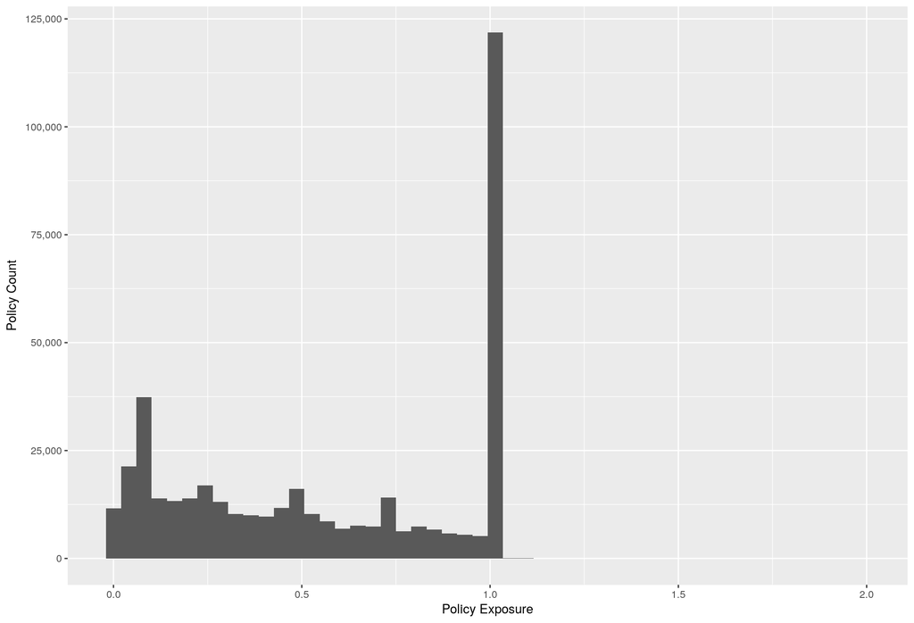

### driver_age

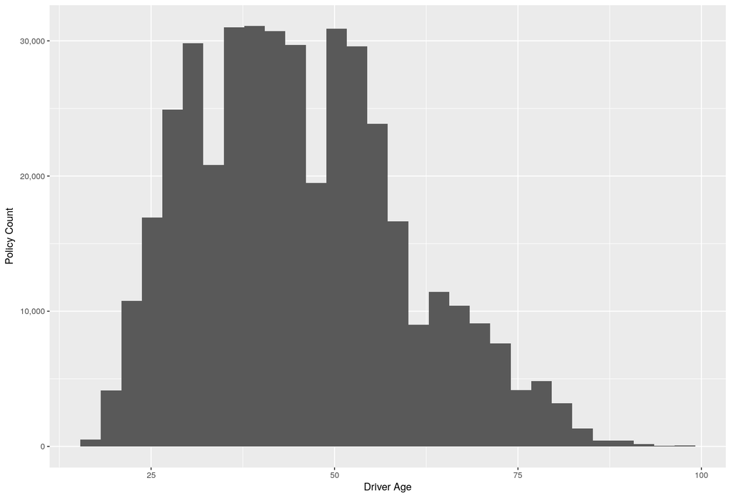

### car_age

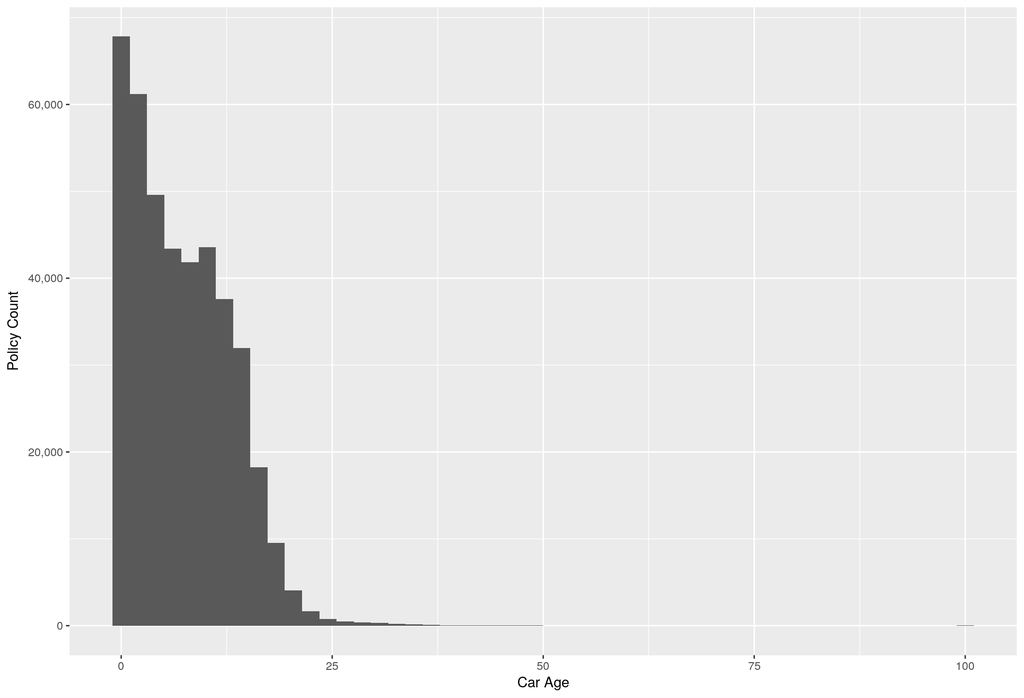

# Bivariate Exploration

Look at two variables at once

Boxplots, Scatterplots, Heatmaps, etc

### claim_count vs driver_age

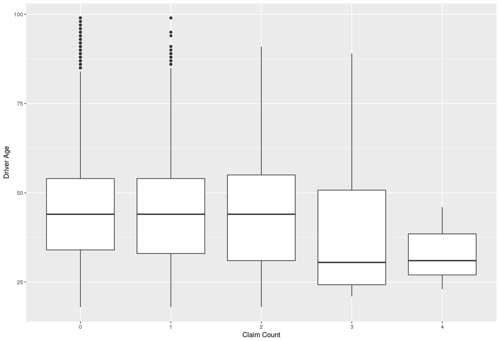

### claim_count vs region

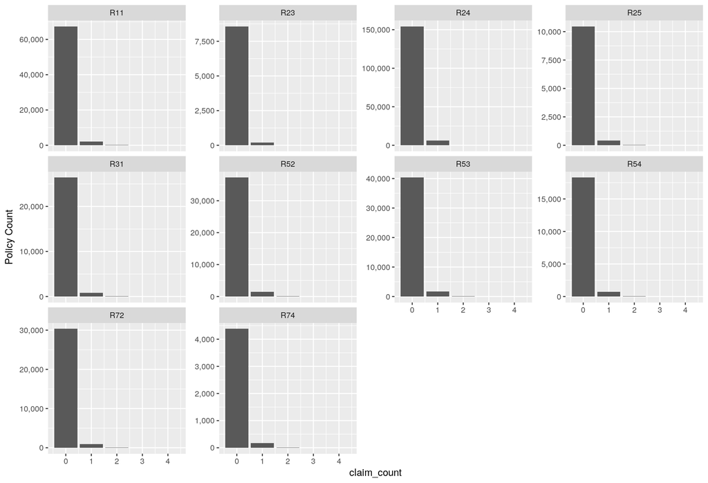

# Power-law Scaling

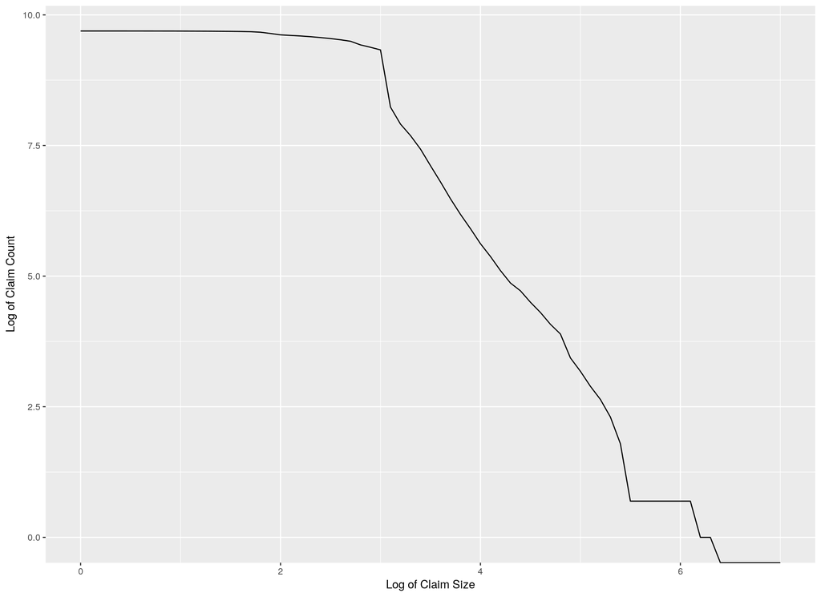

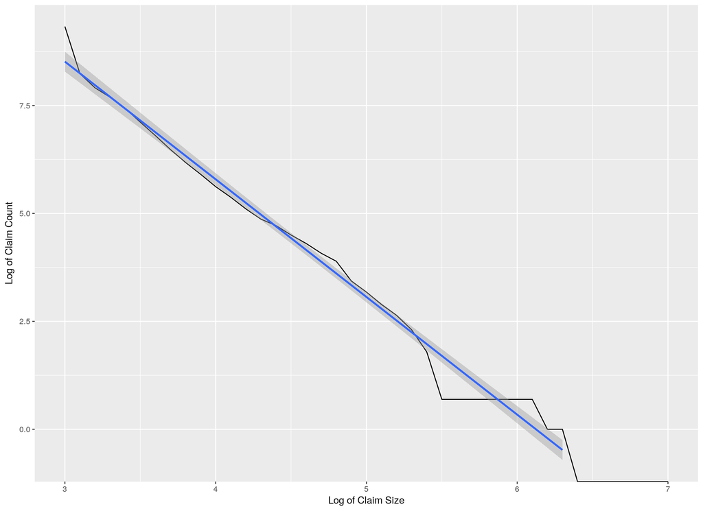

### Proposed Approach

$$\text{Premium} = \text{Claim Rate} \times \text{Claim Size} + \text{Large Claim Charge}$$
Claim rate more predictive power

# Generalized Linear Models

# Basic Concept

$$E(\mathbf{Y}) = \mu = g^{-1}(\text{X} \beta)$$
where

$$\begin{align*}
\mathbf{Y} &= \text{response variable} \\
\mathbf{X} &= \text{predictor variables} \\
\beta &= \text{model coeffcients} \\
g(x) &= \text{link function}
\end{align*}$$

Combines multiple forms of regression

Poisson regression $\longrightarrow g(x) = \log(x)$

Gamma regression $\longrightarrow g(x) = \frac{1}{x}$

# Modelling Claim Rate

Assuming claims occur as Poisson process

Regression predicts poisson rate for policy

Need to investigate variables

### Overall Claim Rate

```r
combined_tbl %>%
    summarise(claim_rate = sum(claim_count) / sum(exposure))
```

```
## # A tibble: 1 × 1
##   claim_rate
##        <dbl>
## 1  0.0697986
```

### Claim Rate by Region

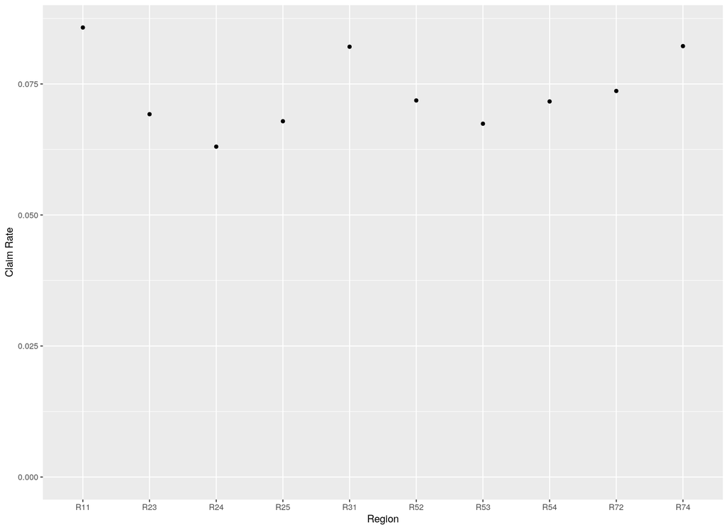

### Claim Rate by Driver Age

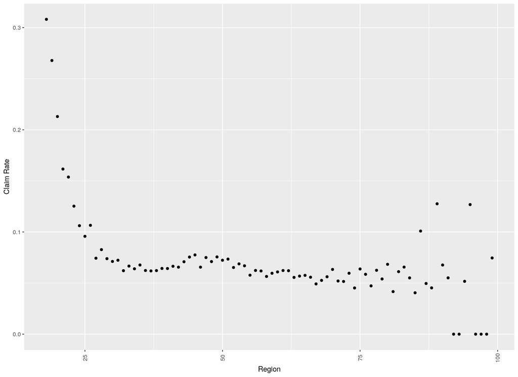

### Binning driver_age

```r
combined_tbl <- combined_tbl %>%
    mutate(cat_driver_age = cut(driver_age, c(17, 22, 26, 42, 74, Inf)))

combined_tbl %>%
    count(cat_driver_age)
```

```
## # A tibble: 5 × 2
##   cat_driver_age      n
##           <fctr>  <int>
## 1        (17,22]  11250
## 2        (22,26]  21109
## 3        (26,42] 158242
## 4        (42,74] 207882
## 5       (74,Inf]  14686
```

### First Poisson Model

```r
gas_glm <- glm(claim_count ~ 0 + gas
              ,offset = log(exposure)
              ,data   = combined_tbl
              ,family = poisson)
summary(gas_glm)
```

```
##
## Call:
## glm(formula = claim_count ~ 0 + gas, family = poisson, data = combined_tbl,
##     offset = log(exposure))
##
## Deviance Residuals:
##    Min      1Q  Median      3Q     Max
## -0.509  -0.361  -0.265  -0.149   6.586
##
## Coefficients:
##            Estimate Std. Error z value Pr(>|z|)
## gasDiesel   -2.5946     0.0109    -238   <2e-16 ***
## gasRegular  -2.7310     0.0114    -240   <2e-16 ***
## ---
## Signif. codes:  0 '***' 0.001 '**' 0.01 '*' 0.05 '.' 0.1 ' ' 1
##
## (Dispersion parameter for poisson family taken to be 1)
##
##     Null deviance: 450747  on 413169  degrees of freedom
## Residual deviance: 105537  on 413167  degrees of freedom
## AIC: 136799
##
## Number of Fisher Scoring iterations: 6
```

```
##
## Call:
## glm(formula = claim_count ~ gas + cat_driver_age, family = poisson,
##     data = combined_tbl, offset = log(exposure))
##
## Deviance Residuals:
##    Min      1Q  Median      3Q     Max
## -0.650  -0.348  -0.265  -0.150   6.619
##
## Coefficients:
##                        Estimate Std. Error z value Pr(>|z|)
## (Intercept)             -1.5738     0.0349  -45.09   <2e-16 ***
## gasRegular              -0.1488     0.0159   -9.38   <2e-16 ***
## cat_driver_age(22,26]   -0.5840     0.0460  -12.68   <2e-16 ***
## cat_driver_age(26,42]   -1.0630     0.0364  -29.24   <2e-16 ***
## cat_driver_age(42,74]   -1.0802     0.0355  -30.46   <2e-16 ***
## cat_driver_age(74,Inf]  -1.1543     0.0518  -22.27   <2e-16 ***
## ---
## Signif. codes:  0 '***' 0.001 '**' 0.01 '*' 0.05 '.' 0.1 ' ' 1
##
## (Dispersion parameter for poisson family taken to be 1)
##
##     Null deviance: 105613  on 413168  degrees of freedom
## Residual deviance: 104646  on 413163  degrees of freedom
## AIC: 135915
##
## Number of Fisher Scoring iterations: 6
```

```
##
## Call:
## glm(formula = claim_count ~ gas + cat_driver_age, family = poisson,
##     data = combined_tbl, offset = log(exposure))
##
## Deviance Residuals:
##    Min      1Q  Median      3Q     Max
## -0.650  -0.348  -0.265  -0.150   6.619
##
## Coefficients:
##                        Estimate Std. Error z value Pr(>|z|)
## (Intercept)             -2.6369     0.0152 -173.90   <2e-16 ***
## gasRegular              -0.1488     0.0159   -9.38   <2e-16 ***
## cat_driver_age(17,22]    1.0630     0.0364   29.24   <2e-16 ***
## cat_driver_age(22,26]    0.4790     0.0342   14.01   <2e-16 ***
## cat_driver_age(42,74]   -0.0172     0.0175   -0.98    0.326
## cat_driver_age(74,Inf]  -0.0913     0.0419   -2.18    0.029 *
## ---
## Signif. codes:  0 '***' 0.001 '**' 0.01 '*' 0.05 '.' 0.1 ' ' 1
##
## (Dispersion parameter for poisson family taken to be 1)
##
##     Null deviance: 105613  on 413168  degrees of freedom
## Residual deviance: 104646  on 413163  degrees of freedom
## AIC: 135915
##
## Number of Fisher Scoring iterations: 6
```

# Modelling Claim Size

Claim size always positive

Look at distribution of log of claims

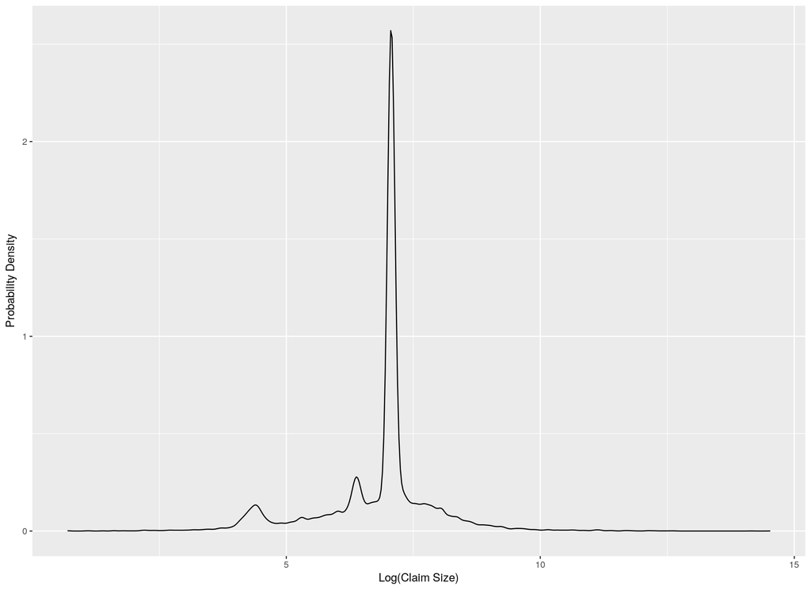

```
##
## Call:
## lm(formula = log(claim_amount) ~ gas + power + car_age, data = claimreg_tbl)
##
## Residuals:
##    Min     1Q Median     3Q    Max
## -6.238 -0.276  0.221  0.321  7.685
##
## Coefficients:
##             Estimate Std. Error t value Pr(>|t|)
## (Intercept)  6.86977    0.02946  233.18  < 2e-16 ***
## gasRegular  -0.01140    0.01885   -0.60  0.54539
## powere      -0.01376    0.03092   -0.44  0.65633
## powerf       0.00498    0.03032    0.16  0.86965
## powerg       0.01537    0.03005    0.51  0.60894
## powerh       0.04554    0.04292    1.06  0.28863
## poweri       0.06298    0.04743    1.33  0.18425
## powerj       0.08620    0.04796    1.80  0.07232 .
## powerk      -0.00791    0.06180   -0.13  0.89816
## powerl       0.06077    0.09103    0.67  0.50443
## powerm       0.08186    0.12991    0.63  0.52862
## powern      -0.27282    0.15074   -1.81  0.07033 .
## powero      -0.21057    0.15354   -1.37  0.17026
## car_age     -0.00614    0.00169   -3.64  0.00028 ***
## ---
## Signif. codes:  0 '***' 0.001 '**' 0.01 '*' 0.05 '.' 0.1 ' ' 1
##
## Residual standard error: 1.11 on 16167 degrees of freedom
## Multiple R-squared:  0.00172,    Adjusted R-squared:  0.000916
## F-statistic: 2.14 on 13 and 16167 DF,  p-value: 0.00959
```

Multiple-$R^2$ of 0.0017???

What does that even look like?

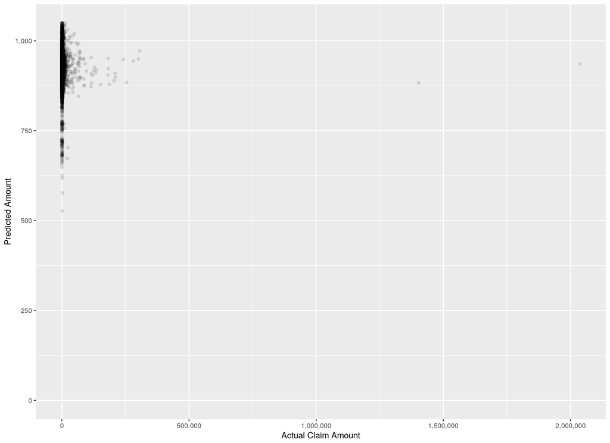

```
##
## Call:
## lm(formula = log(claim_amount) ~ gas + power + car_age, data = claimreg_tbl)
##
## Residuals:
##    Min     1Q Median     3Q    Max
## -6.218 -0.261  0.250  0.347  3.546
##
## Coefficients:
##             Estimate Std. Error t value Pr(>|t|)
## (Intercept)  6.84950    0.02809  243.88  < 2e-16 ***
## gasRegular  -0.01886    0.01798   -1.05  0.29411
## powere      -0.01439    0.02946   -0.49  0.62536
## powerf      -0.01186    0.02891   -0.41  0.68177
## powerg       0.00281    0.02865    0.10  0.92173
## powerh       0.04543    0.04089    1.11  0.26658
## poweri       0.05055    0.04523    1.12  0.26377
## powerj       0.08493    0.04570    1.86  0.06312 .
## powerk      -0.01849    0.05895   -0.31  0.75382
## powerl       0.08146    0.08651    0.94  0.34638
## powerm       0.00230    0.12504    0.02  0.98533
## powern      -0.24806    0.14322   -1.73  0.08330 .
## powero      -0.18532    0.14589   -1.27  0.20401
## car_age     -0.00587    0.00161   -3.64  0.00027 ***
## ---
## Signif. codes:  0 '***' 0.001 '**' 0.01 '*' 0.05 '.' 0.1 ' ' 1
##
## Residual standard error: 1.06 on 16054 degrees of freedom
## Multiple R-squared:  0.00185,    Adjusted R-squared:  0.00105
## F-statistic: 2.29 on 13 and 16054 DF,  p-value: 0.00501
```

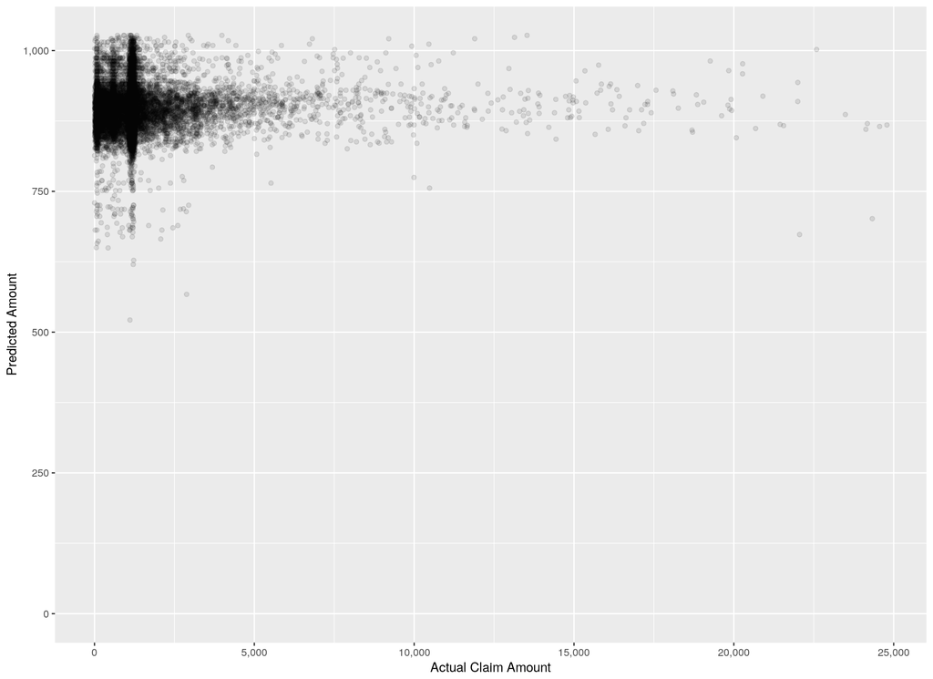

Pretty poor

Fit a Gamma?

```
##
## Call:
## glm(formula = claim_amount ~ gas + power + car_age, family = Gamma(link = "log"),
##     data = claimreg_tbl)
##
## Deviance Residuals:
##    Min      1Q  Median      3Q     Max
## -3.367  -0.640  -0.199  -0.088   5.423
##
## Coefficients:
##              Estimate Std. Error t value Pr(>|t|)
## (Intercept)  7.32e+00   3.39e-02  216.17  < 2e-16 ***
## gasRegular  -1.63e-02   2.17e-02   -0.75    0.453
## powere      -7.61e-03   3.55e-02   -0.21    0.830
## powerf      -5.00e-03   3.48e-02   -0.14    0.886
## powerg       4.60e-02   3.45e-02    1.33    0.183
## powerh       2.00e-02   4.93e-02    0.41    0.685
## poweri       5.94e-02   5.45e-02    1.09    0.276
## powerj       8.06e-02   5.51e-02    1.46    0.143
## powerk      -9.52e-05   7.10e-02    0.00    0.999
## powerl       2.49e-01   1.04e-01    2.39    0.017 *
## powerm       5.93e-02   1.51e-01    0.39    0.694
## powern       2.49e-01   1.73e-01    1.44    0.149
## powero      -1.66e-02   1.76e-01   -0.09    0.925
## car_age     -9.79e-03   1.94e-03   -5.04  4.6e-07 ***
## ---
## Signif. codes:  0 '***' 0.001 '**' 0.01 '*' 0.05 '.' 0.1 ' ' 1
##
## (Dispersion parameter for Gamma family taken to be 1.62946)
##
##     Null deviance: 14681  on 16067  degrees of freedom
## Residual deviance: 14613  on 16054  degrees of freedom
## AIC: 264944
##
## Number of Fisher Scoring iterations: 6
```

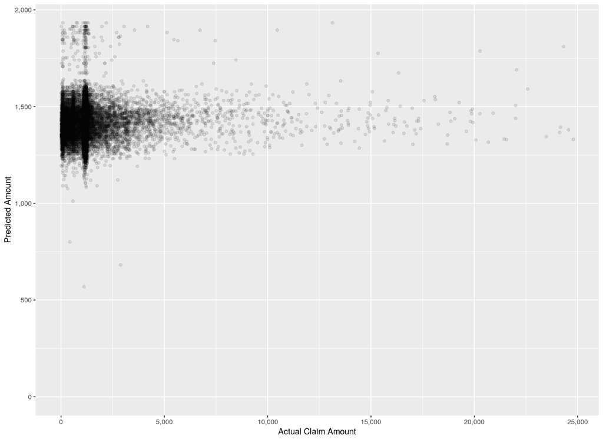

Best to have low expectations

# Building a Premium Quoter

# Data Preparation

Remove rows:

- Drivers older than 75 years
- Cars older than 20 years

```
## [1] 395068
```

### Split Data

Standard Train/Validate/Test split

Take 100,000 policies for test

```r
train_tbl %>% nrow
```

```
## [1] 244974
```

```r
valid_tbl %>% nrow
```

```
## [1] 50000
```

```r
testpolicies_tbl  %>% nrow
```

```
## [1] 100000
```

### Model Claim Rate

```
##
## Call:
## glm(formula = claim_nb ~ cat_driver_age, family = poisson, data = train_tbl,
##     offset = log(exposure))
##
## Deviance Residuals:
##    Min      1Q  Median      3Q     Max
## -0.614  -0.363  -0.261  -0.148   5.616
##
## Coefficients:
##                        Estimate Std. Error z value Pr(>|z|)
## (Intercept)             -2.6853     0.0172 -156.19   <2e-16 ***
## cat_driver_age(17,22]    1.0154     0.0466   21.79   <2e-16 ***
## cat_driver_age(22,26]    0.4458     0.0437   10.20   <2e-16 ***
## cat_driver_age(42,74]   -0.0330     0.0222   -1.48    0.138
## cat_driver_age(74,Inf]  -0.2529     0.1411   -1.79    0.073 .
## ---
## Signif. codes:  0 '***' 0.001 '**' 0.01 '*' 0.05 '.' 0.1 ' ' 1
##
## (Dispersion parameter for poisson family taken to be 1)
##
##     Null deviance: 62749  on 244973  degrees of freedom
## Residual deviance: 62246  on 244969  degrees of freedom
## AIC: 80873
##
## Number of Fisher Scoring iterations: 6
```

```
##
## Call:
## glm(formula = claim_nb ~ gas + cat_driver_age + car_age + density +
##     cat_driver_age:gas, family = poisson, data = train_tbl, offset = log(exposure))
##
## Deviance Residuals:
##    Min      1Q  Median      3Q     Max
## -0.808  -0.346  -0.264  -0.149   5.504
##
## Coefficients:
##                                    Estimate Std. Error z value Pr(>|z|)
## (Intercept)                       -2.61e+00   2.74e-02  -95.17  < 2e-16 ***
## gasRegular                        -1.64e-01   3.50e-02   -4.68  2.8e-06 ***
## cat_driver_age(17,22]              1.00e+00   7.30e-02   13.72  < 2e-16 ***
## cat_driver_age(22,26]              4.30e-01   6.08e-02    7.06  1.6e-12 ***
## cat_driver_age(42,74]             -2.73e-02   2.99e-02   -0.91   0.3609
## cat_driver_age(74,Inf]            -2.78e-03   2.31e-01   -0.01   0.9904
## car_age                           -5.60e-03   2.07e-03   -2.71   0.0067 **
## density                            2.15e-05   1.96e-06   10.98  < 2e-16 ***
## gasRegular:cat_driver_age(17,22]   1.15e-01   9.54e-02    1.21   0.2265
## gasRegular:cat_driver_age(22,26]   5.56e-02   8.76e-02    0.64   0.5253
## gasRegular:cat_driver_age(42,74]   5.58e-03   4.47e-02    0.12   0.9007
## gasRegular:cat_driver_age(74,Inf] -3.04e-01   2.92e-01   -1.04   0.2968
## ---
## Signif. codes:  0 '***' 0.001 '**' 0.01 '*' 0.05 '.' 0.1 ' ' 1
##
## (Dispersion parameter for poisson family taken to be 1)
##
##     Null deviance: 62749  on 244973  degrees of freedom
## Residual deviance: 62077  on 244962  degrees of freedom
## AIC: 80718
##
## Number of Fisher Scoring iterations: 6
```

### Assess Claim Rate Model

Predict claim frequency in train set

MonteCarlo simulation of claim incidence

Compare distribution against observed

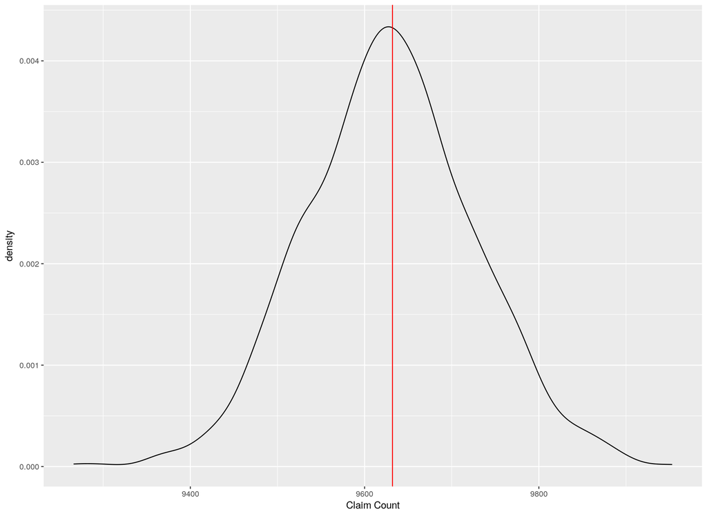

What about the validation set?

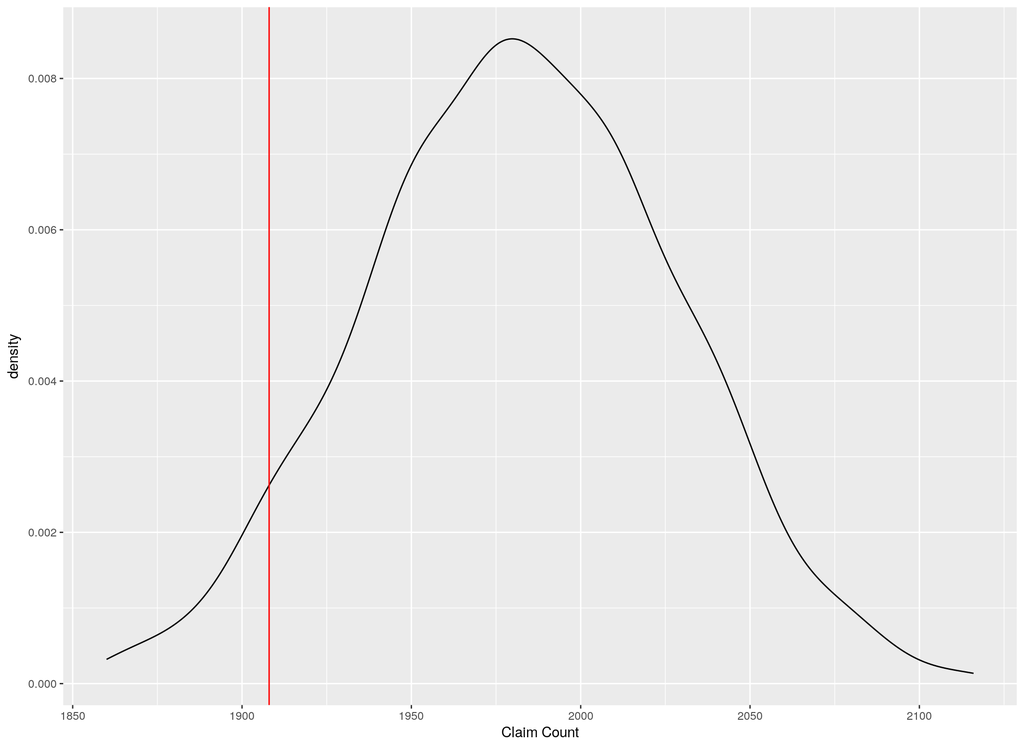

What about claim size?

Models little use

Assume average claim size

```r
claim_tbl %>%
    filter(claim_amount <= 25000) %>%
    summarise(mean_amount = mean(claim_amount))
```

```
## # A tibble: 1 × 1
##   mean_amount
##         <dbl>
## 1     1414.96
```

Use this for claim prediction

### Estimating Large Losses

Treat as completely random

Power-law for Frequency / Severity

```r
pl_tbl <- powerlaw_tbl %>%
    filter(logsize >= 3, count > 0) %>%
    mutate(logcount  = log(count))

pl_lm <- lm(logcount ~ logsize, data = pl_tbl)

pl_scaling <- pl_lm %>% coef %>% nth(2)

pl_scaling %>% print
```

```
## [1] -2.72615
```

Scaling factor $\longrightarrow$ finite mean

```r
expected_loss %>% print
```

```
## [1] 19708.3
```

```r
largeclaim_prop %>% print
```

```
## [1] 0.000273496
```

```r
(largeclaim_prop * expected_loss) %>% print
```

```
## [1] 5.39013
```

Add as charge to all premia

### Create Premium Quoter Function

```
## # A tibble: 6 × 5
##   expect_price largeloss_charge risk_premium quote_price policy_id
##          <dbl>            <dbl>        <dbl>       <dbl>     <int>
## 1      94.8712          5.39013     100.2613    135.3528         2
## 2      42.7991          5.39013      48.1892     65.0554         4
## 3      17.4050          5.39013      22.7951     30.7734         5
## 4      87.0249          5.39013      92.4150    124.7603         6
## 5      74.8226          5.39013      80.2127    108.2871         7
## 6      10.6840          5.39013      16.0741     21.7000        11
```

# Assess the Pricing

### MonteCarlo Simulation of Claims

Simulate claims using poisson model

For each claim, simulate claim size

Compare paid out losses to collected premia

### Test Training Data

Start with the training data

For consistency, this *SHOULD* match

Sanity-check for our approach

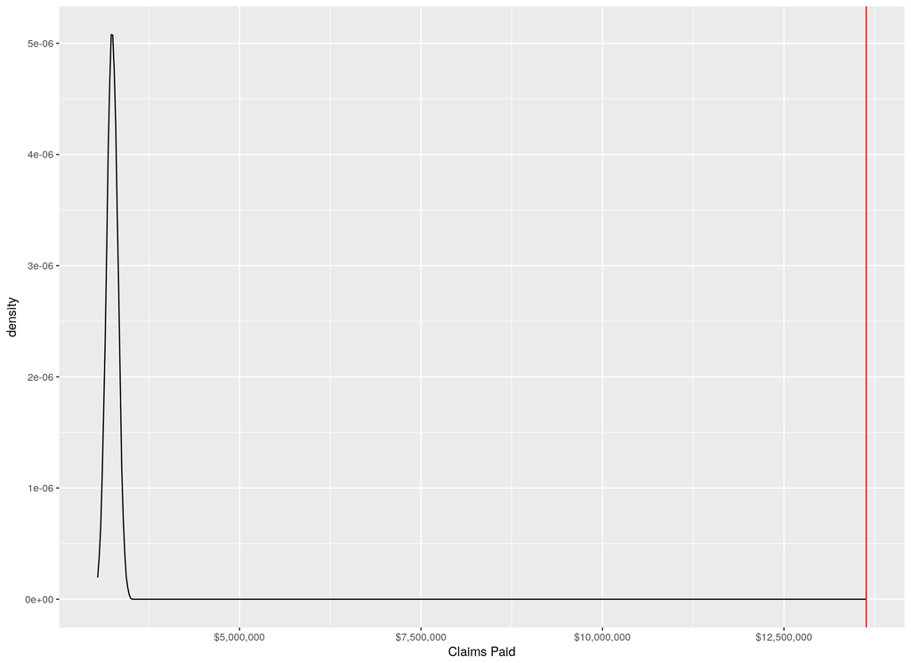

```r
expect_amount <- predict(claimsize_glm, type = 'response')[1]

total_claims    <- claimrate_sim * expect_amount
collect_premium <- pricing_tbl %>%
    summarise(total_premium = sum(expect_price)) %>%
    .[['total_premium']]

ggplot() +
    geom_line(aes(x = total_claims), stat = 'density') +
    geom_vline(aes(xintercept = collect_premium), colour = 'red') +
    scale_x_continuous(labels = dollar) +
    xlab("Claims Paid")
```

# Future Steps

# Problems and Shortcomings

GLMs simplistic, may need overdispersed models

Need more validation / testing

Claims prediction needs work

# Future Improvements

Perform more thorough testing

Use Bayesian version - `stan_glm`

Improve linear models - GAMs

# Questions?

Email: mickcooney@gmail.com

GitHub: https://github.com/kaybenleroll/dublin_r_workshops